# Crickhowell Car Park Stats

*Tom White and Eliane Wigzell, October 2023*

We analysed ticket data for the two machines in Crickhowell’s Long Stay car park from September 2017 to September 2023 that we received from Powys County Council.

We didn’t receive data covering the period June 2019 to December 2020, so that period is missing from the following analysis.

### Ticket prices

Ticket prices were increased in 2019, and most recently in May 2023. From May 2023 the 1 hour tariff was removed.

| Code | Vehicle | Duration | 2017 price | 2019 price | 2023 price |
| --- | --- | --- | --- | --- | --- |
| A | Car | 1 hour | £0.70 | £1.00 | N/A |
| B | Car | 2 hour | £1.30 | £2.00 | £2.50 |
| C | Car | 4 hour | £2.50 | £3.00 | £3.25 |
| D | Car | All day | £3.20 | £4.00 | £4.00 |

The following chart shows the average payment for a ticket (averaged over all tickets for a month), which clearly shows the price increases.

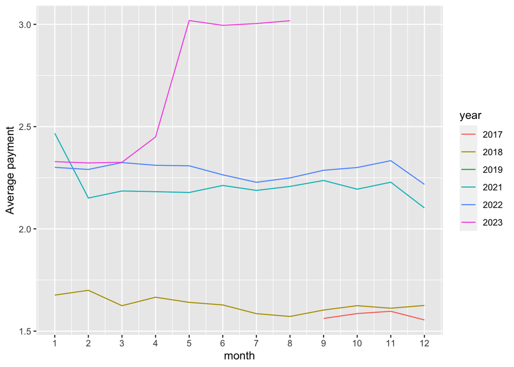

### Number of tickets sold by month and year

There was a big increase in car park usage in summer 2021 from earlier in the year to roughly pre-pandemic levels. Then in 2022 usage dropped back to around or below pre-pandemic levels.

The sales for 2023 to date are very similar to those of 2022. In particular, there is no noticeable drop off in May 2023 as a result of the tariff changes.

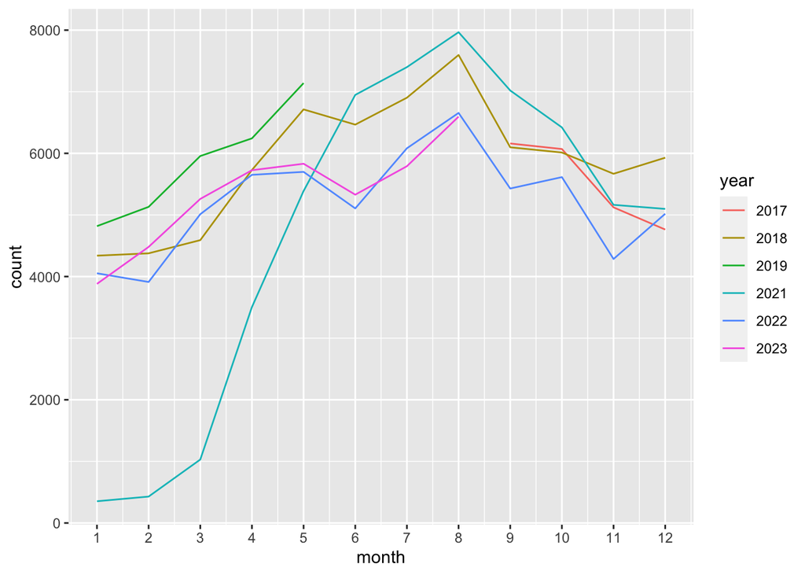

### Revenue

After the 2023 tariff change revenue was markedly up compared to 2022.

(Note that there is no line for 2019 since the data supplied to us had no cash column for that year.)

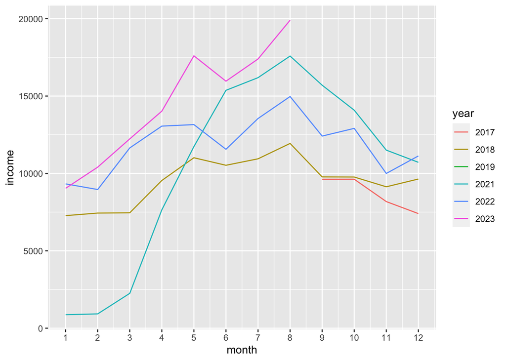

To see how revenue would compare if the 1 hour tariff had been retained, we took the sales for May 2022 and applied the new May 2023 prices to them, including a £1.40 charge for the 1 hour tariff (which is what it is for Powys Short Stay car parks). This assumes that sales for 2023 were broadly the same as 2022, which they were for the first four months of the year.

The projected revenue for May 2023 using this method is £15,037, which is less than the actual revenue in May 2023 of £17,601.

By abolishing the 1 hour tariff Powys County Council have increased revenue (by 34% compared to £13,155 in May 2022), at the expense of the number of visitors to the car park, and possibly to the shops and other amenities of Crickhowell.

However, by keeping the 1 hour tariff Powys could have still increased revenue by 14% (from £13,155 to £15,037) without impacting visitor numbers.

### Tickets sold by day of week

Saturday is by far the busiest day on average, followed by Friday. Sunday is the quietest day.

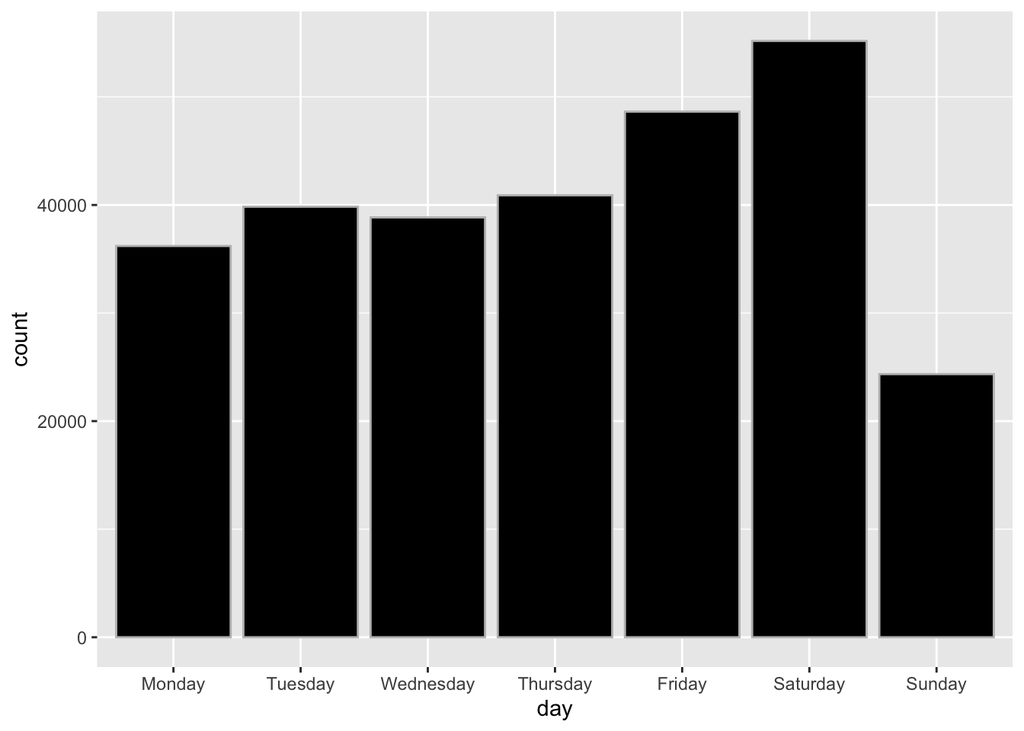

Restricting to 2023, the story is the same, except Tuesdays are slightly more popular than Thursdays.

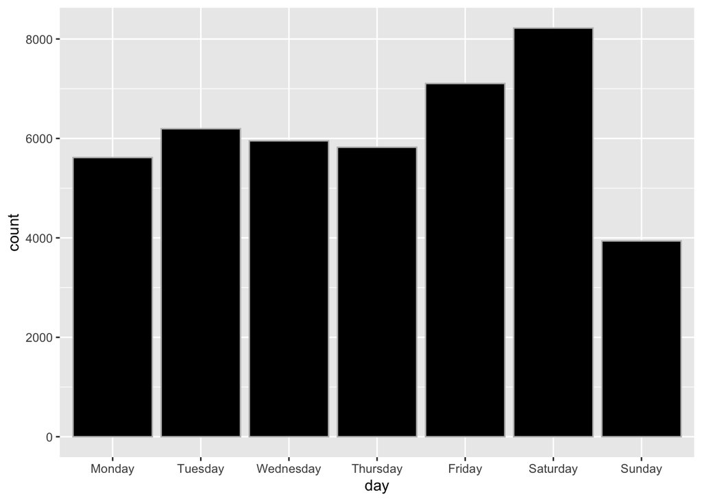

### Tickets sold by hour of day

Most tickets are sold between midday and 1pm.

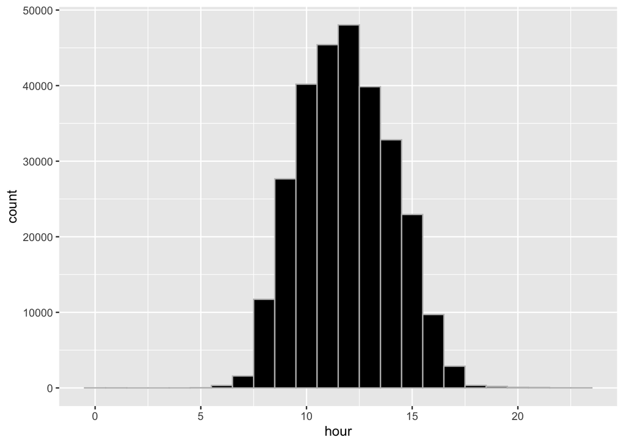

### Tickets sold by type

Before the 2023 tariff changes the 2 hour ticket was the most popular, closely followed by the 1 hour ticket:

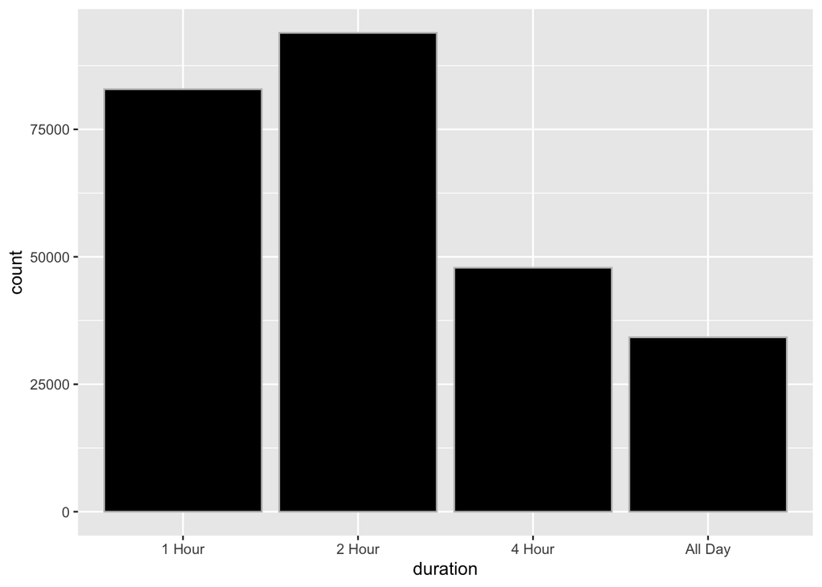

If we break down 2023 sales by month we can see the shift from 1 to 2 hour tickets from late April onwards as it was no longer possible to buy 1 hour tickets.

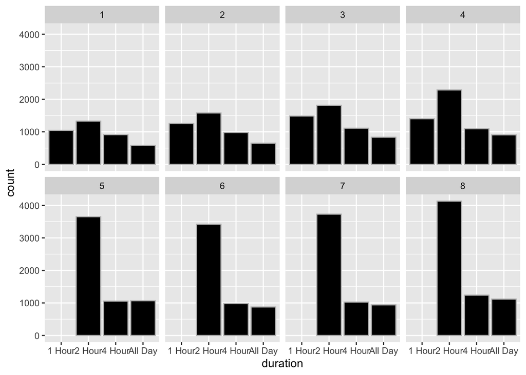